# p8105_hw3_pz2334

Puyuan Zhang

2024-10-08

## Poblem 2

```r
accel = read.csv("data/nhanes_accel.csv") |>
  janitor::clean_names()
combine_data = read.csv("data/nhanes_covar.csv", skip = 4) |>
  janitor::clean_names() |>
  mutate(gender = case_when(
        sex == 1 ~ "Male",
        sex == 2 ~ "Female"),
         education_level = case_when(
           education == 1 ~ "Less than high school",
           education == 2 ~ "High school equivalent",
           education == 3 ~ "More than high school"
         ))|>
  drop_na()|>
  inner_join(accel, "seqn") |>
  filter(age >= 21)
```

```r
combine_data |>
  group_by(education_level) |>
  summarize(Male = sum(gender == "Male"),
            Female = sum(gender == "Female"))
```

```
## # A tibble: 3 × 3
##   education_level         Male Female
##   <chr>                  <int>  <int>
## 1 High school equivalent    35     23
## 2 Less than high school     27     28
## 3 More than high school     56     59
```

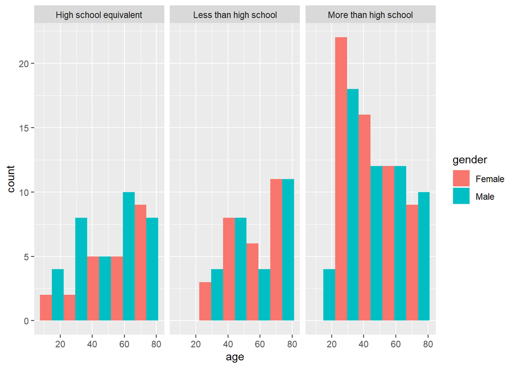

```r
ggplot(combine_data, aes(x = age, fill = gender)) +
  geom_histogram(position = "dodge",bins = 5) +
  facet_grid(~ education_level)
```

For “High School Equivalent”, it shows a realtively even distribution across different age groups for both gender, with a slight increase in frequency around the age of 60s. The counts for males and females are comparable across different ages. This balanced distribution suggests that both men and women have similar opportunities and rates of completing high school, across different ages.

For “Less Than High School”, both genders have similar counts across younger and middle age groups, with a slight increase in 40 and 60. This indicates that older people had fewer chances complete high school. It shows that the lack of completing high school is quite evenly distributed between different genders.

For “More Than High School”, there is a noticeable higher number of females than males in the 20-30 age range. For older ages, the numbers between men and women are similar. The large number of younger women with more than a high school education could suggest that women in this age group either had better access to education or have remained actively involved in educational activities. For older people, the equal numbers suggest that higher education has become more equally accessible to both men and women.

```r
activity_data = combine_data |>
  mutate(total_activity=rowSums(across(starts_with("min")))) |>
  select(-starts_with("min"))
```

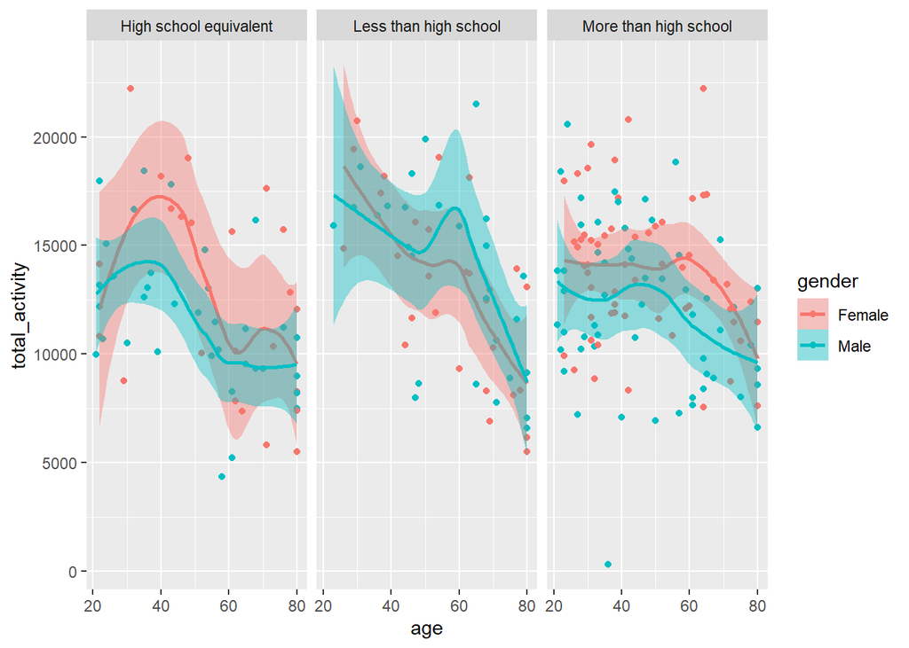

```r
ggplot(activity_data,
       aes(x = age, y = total_activity, fill = gender)) +
  geom_point(aes(color = gender)) +
  geom_smooth(aes(color = gender)) +
  facet_wrap(~ education_level)
```

For the first panel(“High School Equivalent”), activity levels show a general decline with age for males. Trend for female is similar, but before age 40, activities have an increasing trend.

For the “More Than High School” panel, the trend is stabilizing. Comparing to the other 2 panel, for both gender, it does not have a dramaticly decreasing trend. And for every age level in this panel, females are always more active comparing to males.

Acrossing these 3 panels, we may conclude that no matter the education level, younger people are always more active, but how quickly their activity drops off as they age can be different. People with more education are end to stay active as their activity level does not drop dramaticly.

```r
accel_data_long <- combine_data |>
  pivot_longer(
    cols = starts_with("min"),
    names_to = "minute",
    names_prefix = "min",
    values_to = "activity"
  )
average_activity_data <- accel_data_long %>%
  group_by(education_level, gender, minute) %>%
  summarize(average_activity = mean(activity, na.rm = TRUE), .groups = 'drop')
```

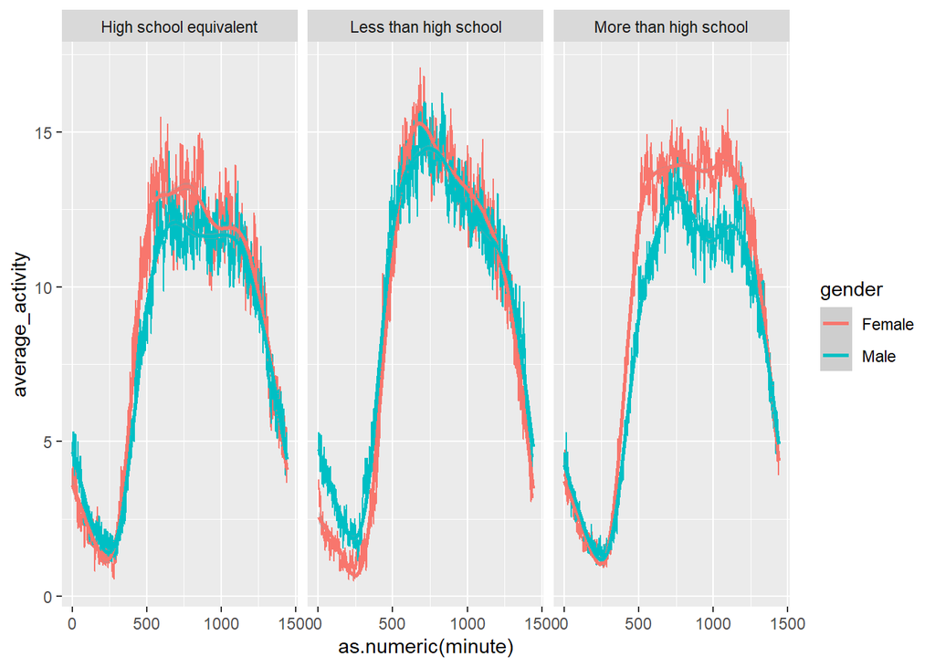

```r
ggplot(average_activity_data, aes(x = as.numeric(minute), y = average_activity, color = gender)) +
  geom_line() +
  geom_smooth()+
  facet_wrap(~ education_level)
```

High School Equivaleng: For both males and females, they display similar activity patterns with a peak at a similar time period, although females show slightly higher activity levels after 250 minutes.

Less Than High School: Both males and females peak at similar times and follow a similar trend. Females are less active at the beginning of the day but then become slightly more active during peak times.

More Than High School: For both men and women, they exhibit similar patterns with two peaks occurring within a short time period. Females seem to be more active throughout the day, especially during peak times.

Generally, acrossing all the education levels, women tend to be more active than men.

## Problem 3

```r
jan_2020 = read.csv("citibike/Jan 2020 Citi.csv") |>
  janitor::clean_names() |>
  mutate(month = "Jan",
         year = 2020)
jan_2024 = read.csv("citibike/Jan 2024 Citi.csv") |>
  janitor::clean_names()|>
  mutate(month = "Jan",
         year = 2024)
july_2020 = read.csv("citibike/July 2020 Citi.csv") |>
  janitor::clean_names() |>
  mutate(month = "July",
         year = 2020)
july_2024 = read.csv("citibike/July 2024 Citi.csv") |>
  janitor::clean_names() |>
  mutate(month = "July",
         year = 2024)
```

```r
combine_bike = jan_2020 |>
  rbind(jan_2024, july_2020, july_2024)
```

```r
combine_bike |>
  group_by(month, year) |>
  summarize(member = sum(member_casual == "member"),
            casual = sum(member_casual == "casual"), .groups = "keep")
```

```
## # A tibble: 4 × 4
## # Groups:   month, year [4]
##   month  year member casual
##   <chr> <dbl>  <int>  <int>
## 1 Jan    2020  11436    984
## 2 Jan    2024  16753   2108
## 3 July   2020  15411   5637
## 4 July   2024  36262  10894
```

```r
july_2024 |>
  group_by(start_station_name) |>
  summarize(n_obs = n()) |>
  arrange(desc(n_obs)) |>
  head(5)
```

```
## # A tibble: 5 × 2
##   start_station_name       n_obs
##   <chr>                    <int>
## 1 Pier 61 at Chelsea Piers   163
## 2 University Pl & E 14 St    155
## 3 W 21 St & 6 Ave            152
## 4 West St & Chambers St      150
## 5 W 31 St & 7 Ave            146
```

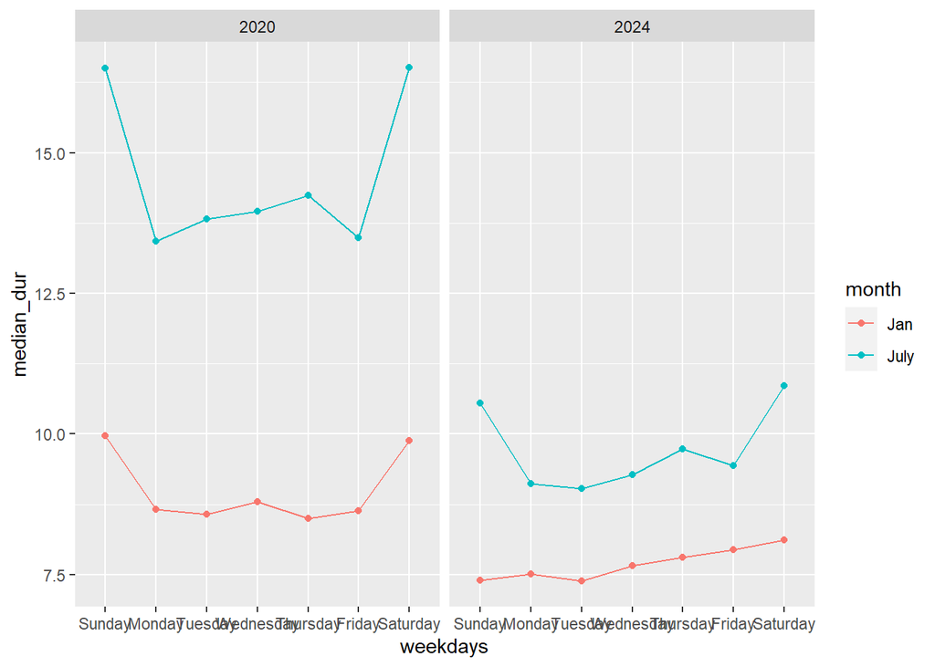

```r
median_duration = combine_bike |>
  group_by(month, year, weekdays) |>
  summarize(median_dur = median(duration), .groups = "keep")

ggplot(median_duration, aes(x = weekdays, y = median_dur, group = interaction(year, month), color = month)) +
  geom_point() +
  geom_line() +
  scale_x_discrete(limits = c("Sunday", "Monday", "Tuesday", "Wednesday", "Thursday", "Friday", "Saturday"))+
  facet_wrap(~ year)
```

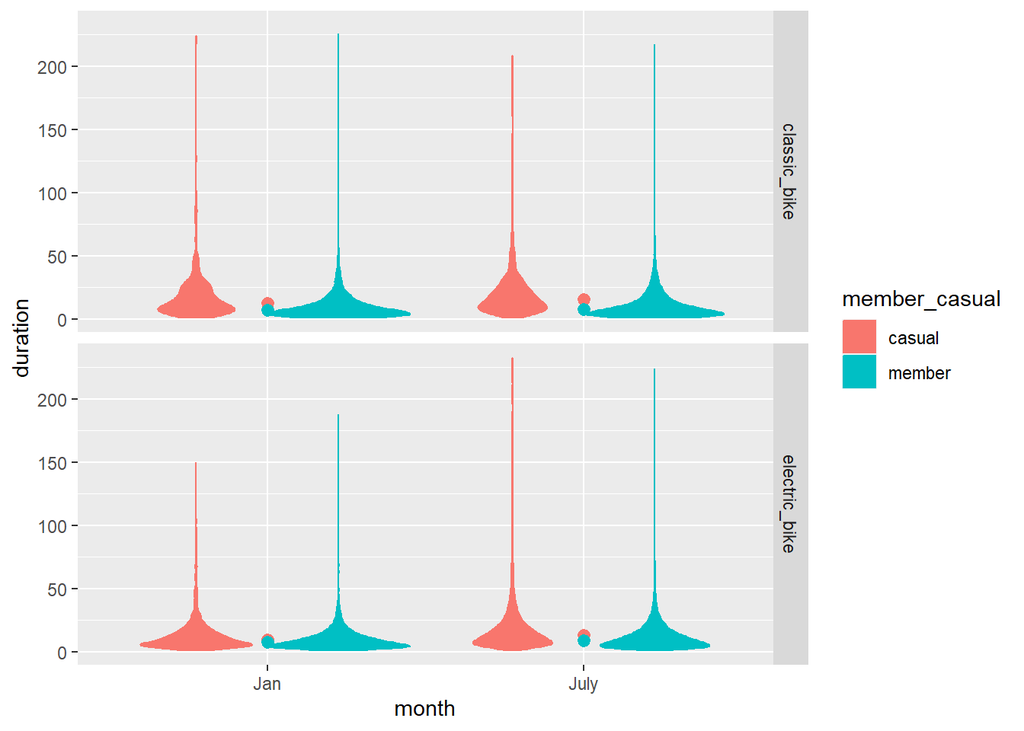

```r
duration_2020 = combine_bike |>
  filter(year == 2024)

ggplot(duration_2020, aes(x = month, y = duration, color = member_casual, fill = member_casual)) +
  geom_violin() +
  stat_summary(fun = "median") +
  facet_grid(rideable_type ~ .)
```

There are two types of bikes, classic and electric, represented in separate rows. The data for January and July show that ride durations are generally shorter in January and longer in July for both types of bikes and both user types. In all cases, casual riders tend to have longer ride durations than members.